# §1. Rates of Return

The following notebook represents notes on rates of return taken from the *Python for Finance: Investment Fundamentals & Data Analytics* Udemy course. All credit for the content of the lecture goes to 365 Cereers.

## Table of Contents:

1. Simple Rate of Return (ROR)
2. Logarithmic Rate of Return (ROR)
3. Portfolio Rate of Return
4. Indices Rate of Return

Let's begin by downloading the requisite data for our analysis.

```python
# Load Libraries
import numpy as np
from pandas_datareader import data as wb
import matplotlib.pyplot as plt

# Grab Procter and Gamble stock
PG = wb.DataReader('PG', data_source = 'yahoo', start = '1995-1-1')
PG.head()
```

| Date | High | Low | Open | Close | Volume | Adj Close |
| --- | --- | --- | --- | --- | --- | --- |
| 1995-01-03 | 15.62500 | 15.43750 | 15.46875 | 15.59375 | 3318400.0 | 6.528558 |
| 1995-01-04 | 15.65625 | 15.31250 | 15.53125 | 15.46875 | 2218800.0 | 6.476228 |
| 1995-01-05 | 15.43750 | 15.21875 | 15.37500 | 15.25000 | 2319600.0 | 6.384644 |
| 1995-01-06 | 15.40625 | 15.15625 | 15.15625 | 15.28125 | 3438000.0 | 6.397724 |
| 1995-01-09 | 15.40625 | 15.18750 | 15.34375 | 15.21875 | 1795200.0 | 6.371559 |

```python
# Check the end of the dataset to confirm our date
PG.tail()
```

| Date | High | Low | Open | Close | Volume | Adj Close |
| --- | --- | --- | --- | --- | --- | --- |
| 2019-02-15 | 99.199997 | 98.250000 | 98.949997 | 98.480003 | 12069100.0 | 98.480003 |
| 2019-02-19 | 100.000000 | 98.470001 | 98.559998 | 99.989998 | 10098200.0 | 99.989998 |
| 2019-02-20 | 100.220001 | 98.940002 | 99.779999 | 99.279999 | 8947400.0 | 99.279999 |
| 2019-02-21 | 99.860001 | 98.589996 | 99.099998 | 99.779999 | 7444800.0 | 99.779999 |
| 2019-02-22 | 100.400002 | 99.400002 | 99.690002 | 100.250000 | 7925400.0 | 100.250000 |

## Simple Rate of Return (SROR)

The difference between the `Close` and the `Adj Close` is that the adjusted closing value takes into account dividends paid to investors as well as stock splits. We will use this value for our calculations.

The simple rate of return is best applied when studying several securities over the *same* time-span.

The simple rate of return is the difference between our present value and our initial investment divided by our initial investment like so:

$ \text{SROR} = \frac{P_{\text{Val}} - P_{\text{Inv}}}{P_{\text{Inv}}} = \frac{P_{\text{Val}}}{P_{\text{Inv}}} - 1 $

Let's run this calculation

```python
# Create new column using the equation
PG['SROR'] = (PG['Adj Close'] / PG['Adj Close'].shift(1)) - 1

# Print 0 - 10 to confirm the ROI is working
print("Daily SROR:\n", PG['SROR'].iloc[0:10])
```

[output not shown]

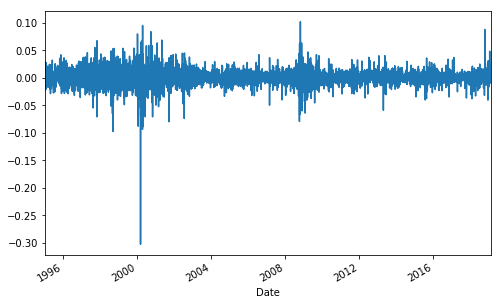

```python
# Visualize results
PG['SROR'].plot(figsize = (8, 5))
plt.show()
```

Remember that the average number of days where the stock market is trading is 250, not 365. With that in mind, let's try finding the average annual ROR:

```python
# Calculate the average daily SROR
aveSROR = (round((PG['SROR'].mean()), 5))
print("Average Daily SROR: ", aveSROR, '%')

# Calculate the average annual SROR
aveSROR = (round((PG['SROR'].mean() * 250), 5) * 100)
print("Average Annual SROR: ", aveSROR, "%")
```

```
Average Daily SROR:  0.00055 %
Average Annual SROR:  13.74 %
```

## Logarithmic Rate of Return (LROR)

The logarithmic rate of return is best used when studying a single security and comparing its return over several time-periods, as opposed to comparing several securities against each other.

$ \text{LROR} = ln\left( \frac{P_{t}}{P_{t-1}} \right) $

Let's run this calculation

```python
# Reprint the data for visualization
PG.head()
```

| Date | High | Low | Open | Close | Volume | Adj Close | SROR |
| --- | --- | --- | --- | --- | --- | --- | --- |
| 1995-01-03 | 15.62500 | 15.43750 | 15.46875 | 15.59375 | 3318400.0 | 6.528558 | NaN |
| 1995-01-04 | 15.65625 | 15.31250 | 15.53125 | 15.46875 | 2218800.0 | 6.476228 | -0.008015 |
| 1995-01-05 | 15.43750 | 15.21875 | 15.37500 | 15.25000 | 2319600.0 | 6.384644 | -0.014142 |
| 1995-01-06 | 15.40625 | 15.15625 | 15.15625 | 15.28125 | 3438000.0 | 6.397724 | 0.002049 |
| 1995-01-09 | 15.40625 | 15.18750 | 15.34375 | 15.21875 | 1795200.0 | 6.371559 | -0.004090 |

```python
# Create new column for daily log return
PG['LROR'] = np.log(PG['Adj Close'] / PG['Adj Close'].shift(1))
print("Daily LROR\n", PG['LROR'].iloc[0:10])
```

```
Daily LROR
 Date
1995-01-03         NaN
1995-01-04   -0.008048
1995-01-05   -0.014243
1995-01-06    0.002047
1995-01-09   -0.004098
1995-01-10    0.012245
1995-01-11   -0.002030
1995-01-12    0.010111
1995-01-13    0.028812
1995-01-16    0.007968
Name: LROR, dtype: float64
```

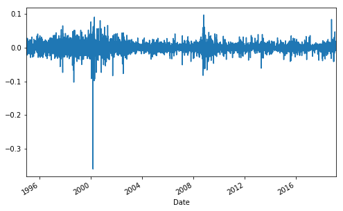

```python
# Visualize results
PG['LROR'].plot(figsize = (8, 5))
plt.show()
```

```python
# Calculate the average daily LROR
aveLROR = (round((PG['LROR'].mean()), 5))
print("Average Daily LROR: ", aveLROR, '%')

# Calculate the average annual LROR
aveLROR = (round((PG['LROR'].mean() * 250), 5) * 100)
print("Average Annual LROR: ", aveLROR, "%")
```

```
Average Daily LROR:  0.00045 %
Average Annual LROR:  11.237 %
```

You can see that the LROR is different from the SROR. Generally, it is preferable to use the LROR when dealing with a single security and comparing its return over multiple time periods.

## Portfolios Rates of Return

Portfolios are often composed of multiple assets and asset classes. The rates fo return for each asset is determined and the portfolio's rate of return becomes the vector sum of the weight of the asset and the asset's ROR.

$ \text{Portfolio ROR} = \sum^{Assets} \left( \text{Asset ROR} \cdot \text{Asset Weight} \right) $

For example, consider the following portfolio:

| Security | Weight | Ave. Annual ROR |
| --- | --- | --- |
| APPL | 40 % | 11 % |
| PG | 30 % | 11 % |
| MSFT | 5 % | 9 % |
| GE | 25 % | 7 % |

The the portfolio's over-all ROR would be:

$ \text{Portfolio ROR} = (\omega_{\text{APPL}} \cdot \text{ROR}_{\text{APPL}}) + (\omega_{\text{PG}} \cdot \text{ROR}_{\text{PG}}) + (\omega_{\text{MSFT}} \cdot \text{ROR}_{\text{MSFT}}) + (\omega_{\text{GE}} \cdot \text{ROR}_{\text{GE}}) = (0.40 \cdot 11) + (0.30 \cdot 11) + (0.05 \cdot 9) + (0.25 + 7) = 9.9 \% $

Let's run this calculation using python:

```python
%reset -f

# Load Libraries
import numpy as np
import pandas as pd
from pandas_datareader import data as wb
import matplotlib.pyplot as plt

# Define desired stock tickers
tickers = 'PG MSFT F GE'.split()

# Assemble portfolio
Port = pd.DataFrame()
for t in tickers:
    Port[t] = wb.DataReader(t, data_source = 'yahoo', start = '1995-1-1')['Adj Close']
```

```python
Port.iloc[0:10]
```

| Date | PG | MSFT | F | GE |
| --- | --- | --- | --- | --- |
| 1995-01-03 | 6.528558 | 2.718300 | 3.471492 | 2.975797 |
| 1995-01-04 | 6.476228 | 2.738060 | 3.564892 | 2.975797 |
| 1995-01-05 | 6.384644 | 2.692897 | 3.533757 | 2.983092 |
| 1995-01-06 | 6.397724 | 2.738060 | 3.533757 | 2.968507 |
| 1995-01-09 | 6.371559 | 2.721123 | 3.596028 | 2.939330 |
| 1995-01-10 | 6.450057 | 2.754996 | 3.533757 | 2.961210 |
| 1995-01-11 | 6.436975 | 2.771933 | 3.533757 | 3.004972 |
| 1995-01-12 | 6.502388 | 2.766288 | 3.502626 | 2.997679 |
| 1995-01-13 | 6.692458 | 2.834033 | 3.564892 | 3.034148 |
| 1995-01-16 | 6.745997 | 2.896133 | 3.611596 | 3.070616 |

Before we visually study the returns of the individual securities within the portfolio, we have to normalize the adjusted close pricing with respect to its price at the beginning of our timeframe. This will allow us to equitably compare the securities within the portfolio. We will divide each price by the start of the dataset and multiply is by 100 like so:

$ \frac{P_i}{P_0} \cdot 100 $

We can plot the resulting data with confidence that it is representative.

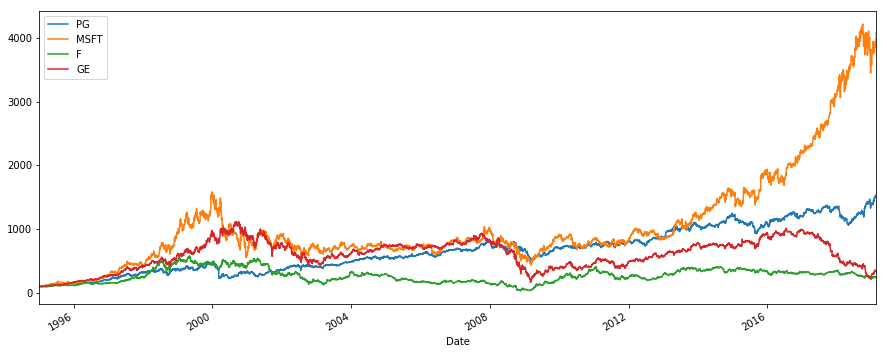

```python
# Call plotting on hypothetical normalized dataframe
(Port / Port.iloc[0] * 100).plot(figsize = (15, 6));

# Illustrate
plt.show()
```

We can see that the data points all begin at 100, indicating that they have been normalized because $(P_0 / P_0) \cdot 100 = 1 \cdot 100 = 100$. We have successfully normalized the data.

Let's create a dataframe for the simple rates of return of each stock and define the weights for the securities within the portfolio. Then the portfolio return will be simply the sum of products of the security returns and weights of the securities.

Remember, we are using the simple rate of return because we are studying multiple securities under the same time frame. The logarithmic rate of return is best used for studying a single security's performance.

```python
# Create and inspect SROR dataframe
SROR = (Port / Port.shift(1)) -1
SROR.head()
```

| Date | PG | MSFT | F | GE |
| --- | --- | --- | --- | --- |
| 1995-01-03 | NaN | NaN | NaN | NaN |
| 1995-01-04 | -0.008015 | 0.007269 | 0.026905 | 0.000000 |
| 1995-01-05 | -0.014142 | -0.016495 | -0.008734 | 0.002451 |
| 1995-01-06 | 0.002049 | 0.016771 | 0.000000 | -0.004889 |
| 1995-01-09 | -0.004090 | -0.006186 | 0.017622 | -0.009829 |

```python
# Calculate the annualized SROR
annual_SROR = round((SROR.mean() * 250), 5) * 100

# Define security weights within the portfolio
weights = np.array([0.25, 0.25, 0.25, 0.25])

# Check if the weights are balanced
if weights.sum() != 1: print('Error: Weights do not add up.')
else: pass

# ---------- Calculate the portfolio SROR ---------- #

# Instantiate at 0
Port_SROR = 0

# Cycle through weights and take a vector sum
for i in range(len(weights)):
    temp = (weights[i] * annual_SROR.iloc[i])
    Port_SROR = Port_SROR + temp

# Print resulting Portfolio SROR
print('Portfolio Simple ROR: ', Port_SROR, '%')
```

```
Portfolio Simple ROR:  13.76725 %
```

Alternatively, we could use the `np.dot()` function to take the dot product.

```python
# Define security weights within the portfolio
weights = np.array([0.25, 0.25, 0.25, 0.25])

# Check if the weights are balanced
if weights.sum() != 1: print('Error: Weights do not add up.')
else: pass

# ---------- CALCULATE THE PORTFOLIO SROR ---------- #

# Run the calculation
Port_SROR = np.dot(annual_SROR, weights)

# Print resulting Portfolio SROR
print('Portfolio Simple ROR: ', Port_SROR, '%')
```

```
Portfolio Simple ROR:  13.76725 %
```

## Indices Rate of Return

Stock indices are an amalgam of stocks and indicators which serve as broad indicators of market health. When determining if your invesments are extraordinary, you must compare the rate of return of your invesments against an the market as a whole. Here we will learn to calculate the return of several popular indices.

```python
# ---------- SETUP ENVIRONMENT ---------- #

%reset -f

import numpy as np
import pandas as pd
from pandas_datareader import data as wb
import matplotlib.pyplot as plt


# ---------- IMPORT DATA FROM YAHOO ---------- #

# Define tickers of interest
tickers = '^GSPC ^IXIC ^GDAXI'.split()

# Instantiate dataframe
Index = pd.DataFrame()

# Import data
for t in tickers:
    Index[t] = wb.DataReader(t, data_source = 'yahoo', start = '1997-1-1')['Adj Close']
```

```python
print(Index.head(5))
print(Index.tail(5))
```

```
                 ^GSPC        ^IXIC       ^GDAXI
Date
1997-01-02  737.010010  1280.699951  2820.810059
1997-01-03  748.030029  1310.680054  2863.260010
1997-01-06  747.650024  1316.400024  2890.199951
1997-01-07  753.229980  1327.729980  2876.340088
1997-01-08  748.409973  1320.349976  2904.080078
                  ^GSPC        ^IXIC        ^GDAXI
Date
2019-02-20  2784.699951  7489.069824  11401.969727
2019-02-21  2774.879883  7459.709961  11423.280273
2019-02-22  2792.669922  7527.540039  11457.700195
2019-02-25  2796.110107  7554.459961  11505.389648
2019-02-26  2796.350098  7557.955566  11540.790039
```

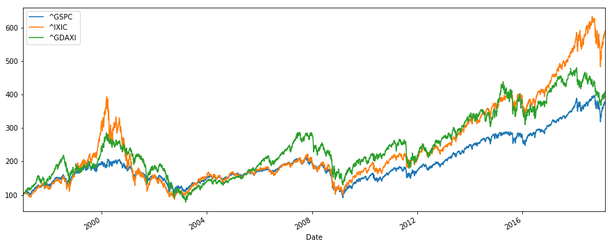

```python
# ---------- PLOT NORMALIZED DATA ---------- #

# Call plotting on hypothetical normalized dataframe
(Index / Index.iloc[0] * 100).plot(figsize = (15, 6));

# Illustrate
plt.show()
```

```python
# ---------- STUDY PORTFOLIO STATISTICS ---------- #

# Create SROR statistics
Index = (Index / Index.shift(1)) - 1

# Find average annual returns
aveSROR = Index.mean() * 250 * 100

# Print results
print("Average Annual Index Returns:\n", aveSROR)
```

```
Average Annual Index Returns:
 ^GSPC      7.791136
^IXIC     11.076795
^GDAXI     7.686158
dtype: float64
```

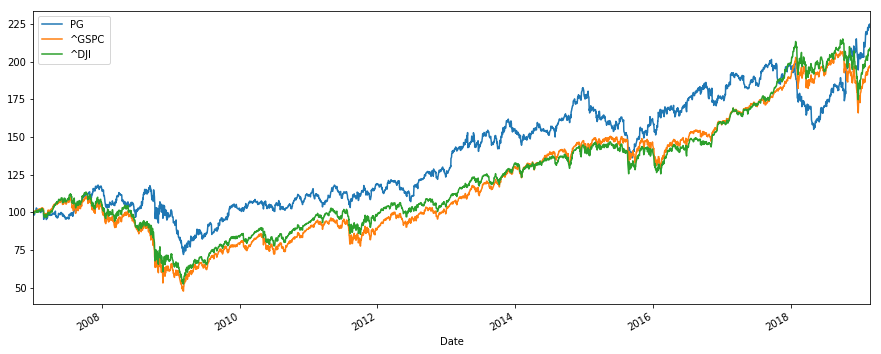

```python
# ---------- COMPARE COMPANY TO INDEXES ---------- #

# Define tickers of interest
tickers = 'PG ^GSPC ^DJI'.split()

# Instantiate dataframe
Port = pd.DataFrame()

# Import data
for t in tickers:
    Port[t] = wb.DataReader(t, data_source = 'yahoo', start = '2007-1-1')['Adj Close']


# ---------- PLOT NORMALIZED DATA ---------- #

# Call plotting on hypothetical normalized dataframe
(Port / Port.iloc[0] * 100).plot(figsize = (15, 6));

# Illustrate
plt.show()
```

**AREAS FOR FURTHER DEVELOPMENT:**

- **Develop Functions**
  - Convert the code in this notebook into a consolidated function for ease of use.

*Notes prepared by Austin Dial on 2/26/2019*